# Exploration of the ARIMA Approach to Time Series Forecasting: A Tutorial in R

## Nikita Amanna, Kate Meldrum, Tyler Valentine

School of Data Science, University of Virginia, Charlottesville, VA, USA

## 1. Motivation

A wide range of industries, including healthcare and finance, rely on time series analysis to inform strategic decision-making. By providing insight into the most likely outcomes given historical trends, these models address critical issues. For example, current applications in the literature include helping medical providers prepare for increased emergency department visits [1] and predicting the occurrence of high-magnitude earthquakes [2]. Auto-regressive integrated moving average (ARIMA), used in both examples, is one of the most common approaches for solving time series problems due to its ability to describe autocorrelations in the data [3]. This tutorial introduces time series analysis and the implementation of ARIMA in the R coding language to solve a variety of interesting problems.

## 2. Time Series and ARIMA

### 2.1 Understanding Time Series Data

Time series data are a collection of sequential observations. It is because of this sequential nature that makes each observation statistically dependent on previous observations and the order of observations matters. With time series analysis, models can provide information about the mean, variance, and correlation between values. However, to obtain estimates for these parameters, they must be constant in time throughout the data set. This property is called stationarity. In general, a stationary time series will have no long-term, predictable patterns, and have constant variance in the parameters throughout its span. Nonstationary time series, in contrast, have predictable trends and non-constant means or variances [3, 4]. An illustration of both stationary and nonstationary time series is shown in Figure 1 [5].

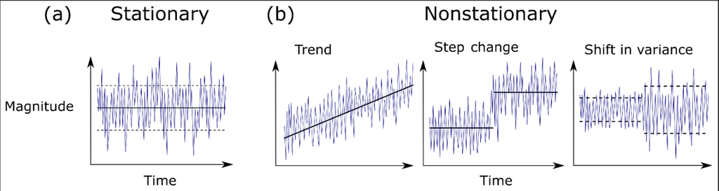

**Figure 1.** An example of a stationary time series with a constant mean and variance and three nonstationary time series.

Data with trends or seasonality are not stationary because the dependence structure changes over time. These features can obscure the behavior of the stationary process and must be removed before analysis of the time series variable. Differencing, one method for reducing trends and seasonality in time series data, involves computing the differences between consecutive observations. The output of this computation is a differenced series (1) [3, 4] An example output of differencing a time series with a positive, linear trend is shown in Figure 2 [6].

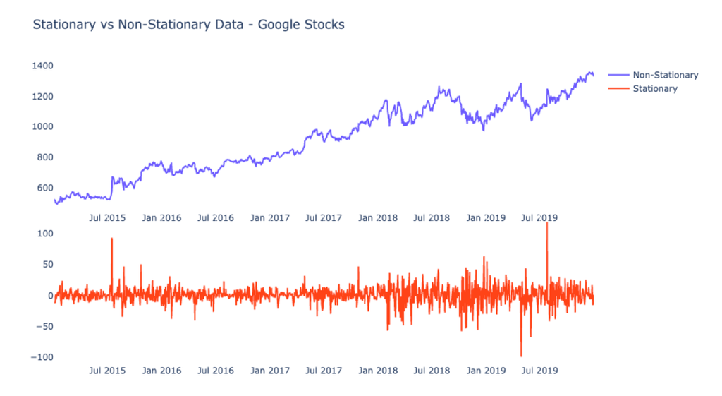

**Figure 2.** Result of differencing a nonstationary time series (blue) to obtain a stationary time series (red) representing changes in Google stock prices.

If the differenced series is white noise, a stationary sequence of uncorrelated observations with a mean of zero, then the original time series can be written as (2) with $ε_t$ denoting the white noise. By rearranging these terms and adding a + c to account for a non-zero mean, the equation for a random walk model is obtained (3). In some cases, the differenced data may not appear stationary, and it may be necessary to difference the data a second time. However, it is usually not necessary to difference more than two times [3, 4].

$(1) \space x'_t=x_t-x_{t-1}$

$(2)\space \epsilon_t=x_t-x_{t-1}$

$(3)\space x_t=c+x_{t-1}+\epsilon_t$

For example, if we wanted to difference a series of average gas prices each year, we might represent the series as the price that year minus the price of the last year ($x_t-x_{t-1}$) plus some constant mean if the mean is nonzero. This would hopefully result in some stationary series, $ε_t$, but since the rate at which gas prices increase is also increasing, in this case we might have to difference a second time to obtain a stationary series.

In some cases, there might be seasonal trends in the data that can be removed with seasonal differencing. This works by comparing values from the same seasonal time instead of values that are directly next to each other. For example, if we were monitoring how much people spend on heat each year, this would increase in the winter, so we could compare the cost every winter, rather than from day to day to create a stationary series. This is modeled with m as the period for a complete cycle of seasons (4). In an example with one data point per month where we wanted to compare months directly, we would use m=12 [3].

$(4) \space x'_t=x_t-x_{t-m}$

### 2.2 Building Blocks of the ARIMA Model

Like a multiple regression model, which predicts a variable of interest with a linear combination of predictors, autoregressive models predict a variable with a linear combination of past values of the variable itself. The term “autoregression” is derived from the act of regressing the variable against itself. An autoregressive model of order p can be expressed as (5). If the past variables of the forecastable variable are replaced with past forecast errors, this is called a moving average model (6) [3, 4].

$(5)\space x_t=c+\phi_1x_{t-1}+\phi_2x_{t-2}+…+\phi_px_{t-p}+\epsilon_t$

$(6)\space x_t=c+\theta_1\epsilon_{t-1}+\theta_2\epsilon_{t-2}+…+\theta_q\epsilon_{t-q}+\epsilon_t$

Combining differencing with the autoregression and moving average models results in a non-seasonal ARIMA model. The full model can be written as (7), where $x'_t$ is the differenced series. This allows for the description of a particular model as ARIMA(p, d, q), where p is the order of the autoregressive part, d is the degree of first differencing, and q is the order of the moving average part [3, 4].

$(7)\space x'_t=c+\phi_1x'_{t-1}+\phi_2x'_{t-2}+…+\phi_px_{t-p}+\theta_1\epsilon_{t-1}+\theta_2\epsilon_{t-2}+…+\theta_q\epsilon_{t-q}+\epsilon_t$

### 2.3 Evaluating ARIMA Models

For given values of p, d, and q, we want to estimate the parameters c, ϕ, and θ in an ARIMA model to obtain optimal predictive performance. Although we can choose to minimize mean squared error (MSE), in practice it is often useful to maximize the log likelihood of the data. The log likelihood is the logarithm of the probability that the observed data came from the estimated model, which is preferred over MSE because this method feeds well into penalizing model complexity using Akaike’s Information Criterion (AIC) [3].

AIC is a statistical measure for the comparative evaluation of time series models. It works by providing an estimation of the information lost when a certain model is used to represent the process that generated data. This means that it provides a balance between the goodness of fit and complexity of the model [7]. For ARIMA, the AIC can be written as (8), where L is the likelihood of the data, k=0 if the mean is zero, and k=1 if the mean is not zero [3].

$(8)\space AIC=-2log(L) +2(p+q+k+l)$

Since AIC has a known tendency to select over-fitted models, a bias-corrected form was developed in 1989 [8]. For ARIMA, the corrected AICc can be written as (9). This estimation is not good at selecting the appropriate order of differencing, since differencing changes the data on which the likelihood is computed, making the AIC values between models noncomparable. Because of this a different method must be used to select d, then AICc can be used to select the best parameters for p and q. The optimal number of differences is determined by using repeated KPSS tests for stationarity. [3].

$(9)\space AICc=AIC+\frac{2(p+q+k+1)(p+q+k+2)}{T-p-q-k-2}$

The KPSS (Kwiatkowski-Phillips-Schmidt-Shin) test for stationarity time series is a type of hypothesis test that has the null hypothesis as a time series being stationary and the alternative hypothesis as the time series being not stationary. The test can be roughly summarized as fitting a linear model to the data and then looking at the intercept, slope, and stationary error. The intercept should have a low margin of error, the slope should have a low value, and the stationary error of the entire model should be relatively small for the test to gain confidence that the time series is stationary. If the null hypothesis is not rejected at a high confidence, the model will assume that the time series does not need to be differenced further [9].

### 2.4 Comparing Forecasting Techniques: ARIMA and Exponential Smoothing

While ARIMA is a popular approach to use for fitting to time series data for the purpose of forecasting, other methods exist that can forecast data points in similar manners but different requirements, namely exponential smoothing. Exponential smoothing is considered a subset of ARIMA models and differs primarily in the way it weights past observations [3], but it is important to understand the differences in popular approaches to assess which method to use for the variety of time series analysis problems that exist across any space.

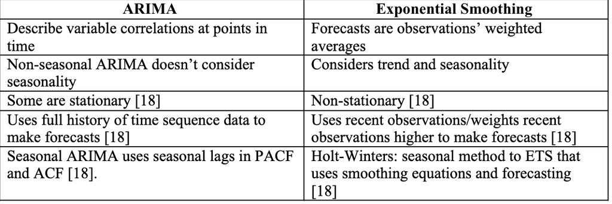

## 3. ARIMA Modeling in R

### 3.1 The fable Package

The R package fable provides methods for displaying and analyzing univariate and multivariate time series forecasting models, including automatic ARIMA modeling. The ARIMA() function is used to search through the model space to identify the best ARIMA model with the lowest AICc value [10].

This function uses a variation of the Hyndman-Khandakar algorithm, which starts by using a KPSS test to determine whether a time series is stationary to select the degree of differentiation, d. The algorithm only considers differences of the orders 0, 1, and 2. Then, after applying that differentiation, the algorithm fits four initial models with standard parameter values for p and q: (0, d, 0), (2, d, 2), (1, d, 0), and (0, d, 1). Out of these models, the one with the lowest initial AICc is chosen. The algorithm then loops through changing parameters by a degree of ±1 until the AICc no longer improves. These optimal parameters are then used in the final model. This process is illustrated in Figure 3 [11].

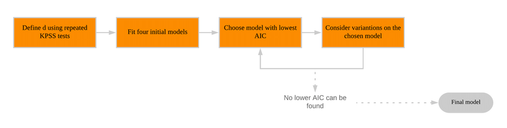

**Figure 3.** Summary of the Hyndman-Khandakar algorithm.

The parameters optimized in steps 3 and 4, p and q, indicate how many previous terms from the autoregressive model and moving average model, respectively, we want to consider. If the algorithm chooses p and q to both be equal to two, this means that the last two terms of the autoregressive model and the last two terms of the average model would be considered in predicting the current value [3].

### 3.2 Steps for Building an ARIMA Model

The first step to ARIMA modeling is plotting the time series data. It is important to look out for unexpected observations, such as outliers. If there is unequal variance in the data, this can be addressed by applying a transformation. One example is the Box-Cox transformation, which stabilizes the variance by normalizing the data. Next, the automated ARIMA() algorithm can be used to determine the best model to fit the time series [3].

After obtaining a model, an autocorrelation function (ACF) plot of the residuals can be used to verify stationarity. For a stationary time-series, the ACF residuals will have a constant variance around zero. For nonstationary time series, however, there will be a slow decrease in the residuals and the values will often be large and positive [3]. An example from the literature is shown in Figure 4 [12]. The residuals should appear to be white noise. To verify this, a portmanteau test can be used to determine whether the autocorrelations at multiple lags of the time series are different from zero [13].

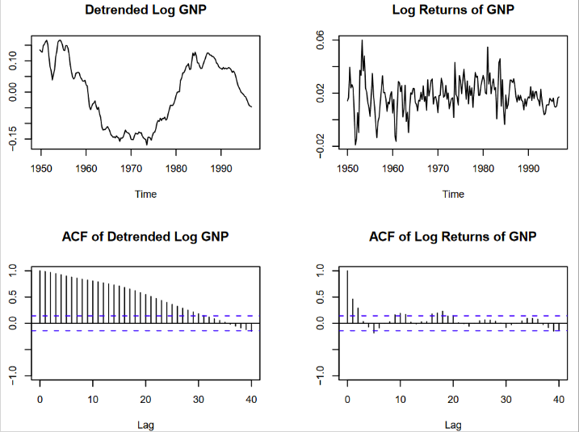

**Figure 4.** An example of ACF residual plots for stationary and nonstationary time series data.

### 3.3 Forecasting in R

The main purpose of modeling time series with ARIMA is to predict the values at future times. Recall that we do not have predictor variables for our time series, so to predict future values all we need to consider is the fit of previous points in the time series as determined by the ARIMA() function, as well as how far into the future we wish to predict. To obtain point forecasts, we use these steps [3].

1. Using the ARIMA equation, expand the equation to make y_t the only part of the left-hand side

2. Replace t with T+h.

Assuming that we have all observations till time T, we can replace t with T+ the current h

3. Replace future observations with their forecasts, future errors with zero, and past errors with the corresponding residuals.

We can calculate all terms except for $\epsilon_{t+1}$, which we can set equal to 0 and $\epsilon_t$ which we set equal to $e_T$ , if the case is for $y_{t+1}$ . To continue the process, we would continue to replace the error terms with 0.

From h = 1 to the last value for which we want to calculate the steps ahead, we calculate the forecasts.

### 3.4 Function information for Modeling and Forecasting with fable

More information on all functions can be found in the official documentation [14], two very common functions, ARIMA and forecast are outlined with some key parameters below.

**ARIMA()**

*formula: insert a formula indicating model structure*

*ic: indicate ‘aic’, ‘aicc’, ‘bic’ to specify model criteria (defaults to aicc)*

*order_constraint: maximum value for p+q+P+Q, where p and q are for the nonperiodic contribution of the model and P and Q are for the periodic contribution of the model (defaults to 6)*

**forecast.ARIMA()**

*object: ARIMA model to be base for forecast*

*bootstrap: if TRUE, bootstrapping is used in forecast predictions (defaults to FALSE)*

*times: number of bootstraps used if bootstraps is true*

## 4. ARIMA in Action

### 4.1 ARIMA with fable: Predicting COVID-19 Cases in Singapore

This example uses data from covid tracking in Singapore [10, 15]. The time series we used to forecast is a record of confirmed covid cases each day. We chose to use days 575 to 800 of this data because there was a large period during the first year where Singapore stopped reporting their cases, and reporting picked up again around day 575, or summer of the second year.

#### First import relevant packages:

```r
library(fable) #main libarary for arima/formatting
library(tidyverse) #plotting
library(feasts) #helper library for fable
library(MASS) #to get optimal lambda using the boxcox function
library(sae) #to actually implement the boxcox since this library is simpler
```

#### Then get our clean time series data:

```
## Plot variable not specified, automatically selected `.vars = Cases`
```

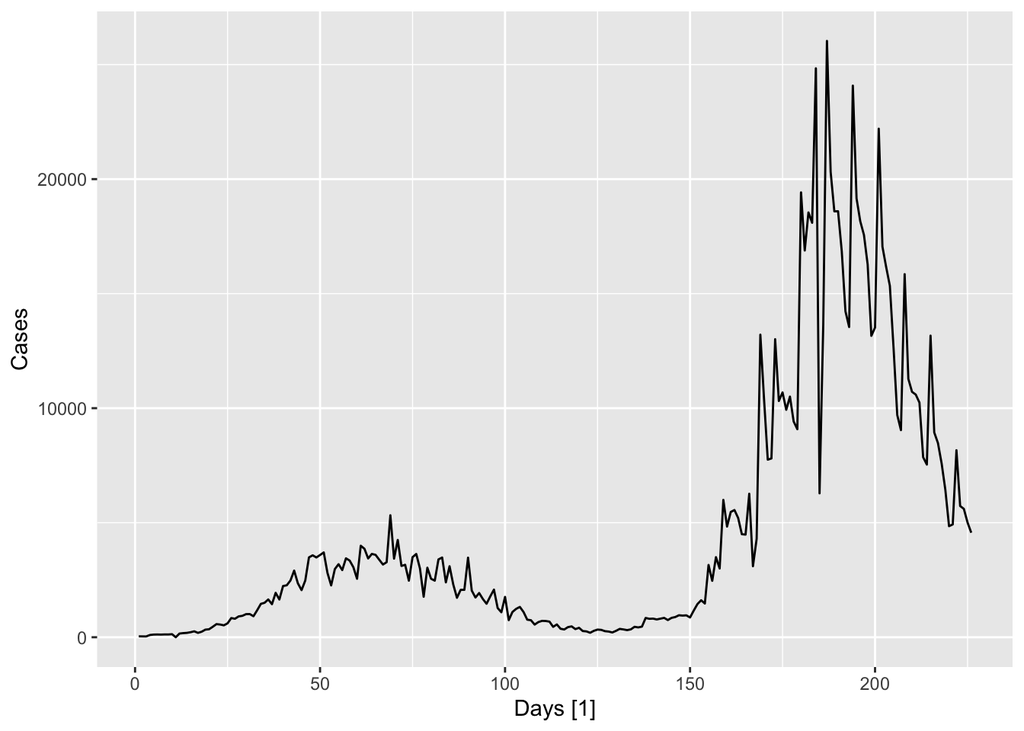

```r
# read in data
setwd('/Users/meldrumapple/Desktop')
data <- read.csv('covid.csv')
# cut data to days 575:800 of covid (less NAs here), make into dataframe
data <- (data[575:800,1])
datadf <- data.frame('Cases'=data)
datadf['Days'] <- c(1:nrow(datadf))
#plot true values of known data
autoplot(as_tsibble(datadf, index=Days))
```

#### Account for Changing Variance:

Since the variance of cases is not constant over time (less variance in the first peak, bigger variance in the second) we need to do a box cox transformation to make our variance more uniform before we give this data to the fable library, which only does differentiation in its modeling.

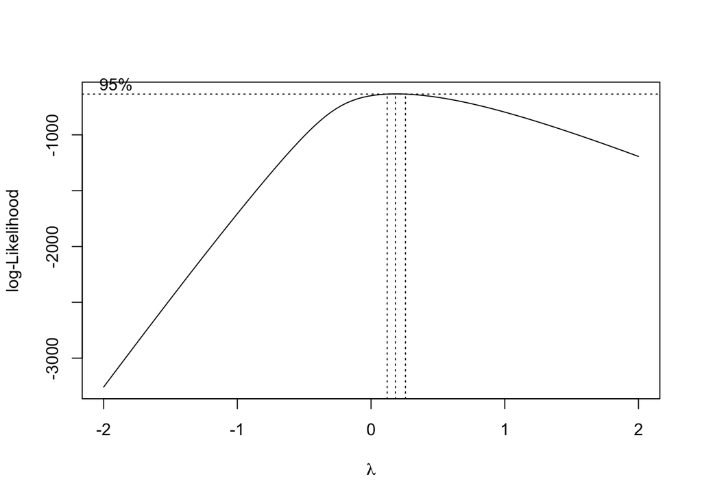

```r
#Use MASS boxcox to find ideal lambda for boxcox transformation
mod <- boxcox(data+1~c(1:nrow(datadf)))
```

```r
mod$x[which.max(mod$y)]
```

```
## [1] 0.1818182
```

```r
lambda=0.1818182
```

```r
#apply box cox with ideal lambda using sae package
datadf$Cases <- bxcx(datadf$Cases, lambda)
```

```
## min data value <= 0, 0.25-min(x) added to data
```

```
## Plot variable not specified, automatically selected `.vars = Cases`
```

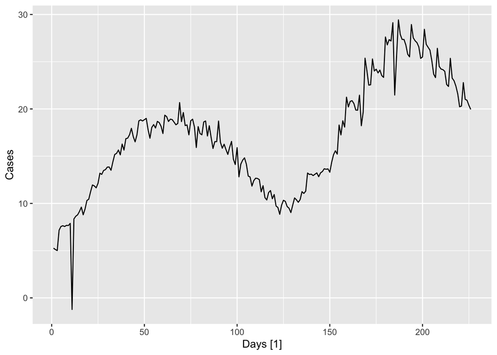

```r
autoplot(as_tsibble(datadf, index=Days))
```

#### Modeling

Our variance looks much more uniform now, so we can move on to modeling.

```r
# fit the arima model to the time series
model.arima <- as_tsibble(datadf, index=Days) %>%
  model(arima=ARIMA(Cases))
# print out stats on our obtained model
model.arima %>% report()
```

```
## Series: Cases
## Model: ARIMA(0,1,1) w/ drift
##
## Coefficients:
##           ma1  constant
##       -0.5208    0.0669
## s.e.   0.0535    0.0454
##
## sigma^2 estimated as 2.022:  log likelihood=-397.65
## AIC=801.29   AICc=801.4   BIC=811.54
```

```r
# obtain forecast for next 20 days
forecast <- model.arima %>% forecast(h=20)
```

Now that we used our model to get a forecast for the next 20 days, we can remove the box cox transformation and plot the original data as well as the predictions.

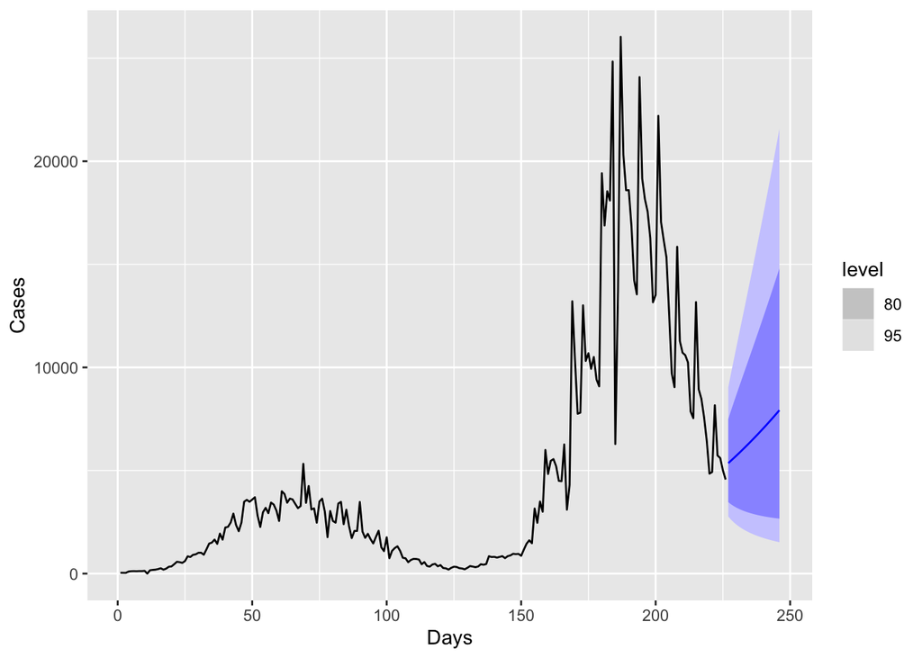

```r
#remove boxcox transformation from forecast
forecast$Cases <- bxcx(forecast$Cases, lambda, InverseQ=TRUE)
#remove boxcox transformation from data before forecast
datadf$Cases <- bxcx(datadf$Cases, lambda, InverseQ=TRUE)
# plot both
  forecast%>%
   autoplot(as_tsibble(datadf, index=Days))
```

We can see that our model now has predicted an upward trend for the next 20 days where the dark blue line is the predicted point, the medium blue region is the 80% confidence interval for this prediction, and the light blue region is the 95% confidence interval for this region.

### 4.2 ARIMA with forecast: Predicting COVID-19 Vaccine Demand

Another useful application of time series forecasting is predicting the daily demand for COVID-19 vaccines. This is important because medical professionals must prepare for future demand to ensure that a sufficient number of vaccines are available. Also, if too many vaccines are ordered and are not needed, then these unneeded vaccines could expire and be wasted.

Data for this example were obtained from Our World in Data, and include daily vaccine doses administered from December 14, 2020 to December 6, 2022. Source: https://ourworldindata.org/grapher/daily-covid-19-vaccination-doses?tab=chart&yScale=log&country=~USA

#### Import Relevant Libraries:

For this example, we decided to use the forecast package in R.

```r
library(tidyverse)
library(forecast)
library(feasts)
```

#### Import and Plot the Data:

Here we show the results of plotting the data. There appears to be large changes in the variance over time, since the bulk of vaccine doses were administered in the months after they were first available.

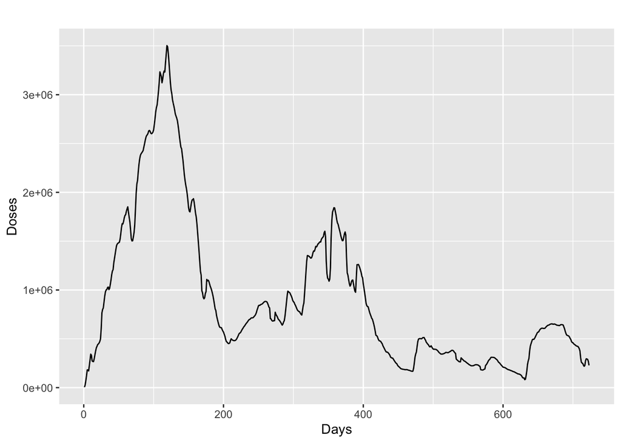

```r
# Import COVID-19 daily vaccination data
data <- read.csv('covid_vaccine_doses.csv', header=FALSE)[, 2]
data <- data.frame('Doses'=data)

# Show plot of the data
autoplot(ts(data)) +
  labs(x='Days', y='Doses')
```

#### Address Non-Constant Variance:

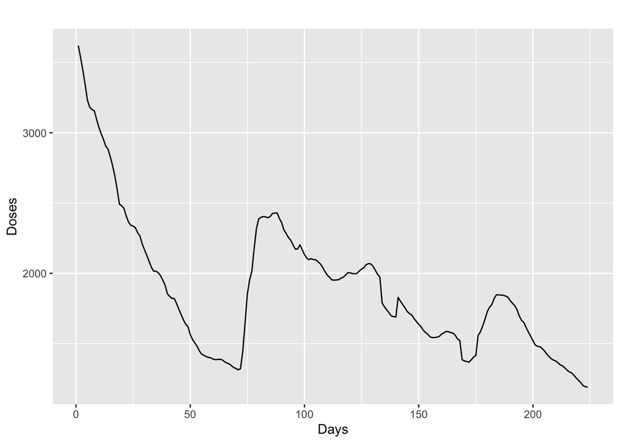

```r
lambda <- BoxCox.lambda(data[400:623, 1])
autoplot(BoxCox(ts(data[400:623, 1]), lambda)) +
        labs(x='Days', y='Doses')
```

After applying this transformation, the variance is more stable. We can now proceed to the next step of fitting an ARIMA model.

#### Fit ARIMA Model

We can fit an ARIMA model to our training data using the auto.arima() function. Using this function, we can define the lambda value we obtained to apply a Box Cox transformation to the data. We can also use a bias adjustment to account for the Box Cox transformation to allow us to forecast using our original data scale.

```r
# Fit model
fit <- data[400:623, 1] %>%
  auto.arima(lambda=lambda, biasadj=TRUE)

# Show best ARIMA model
summary(fit)
```

```
## Series: .
## ARIMA(1,2,1)
## Box Cox transformation: lambda= 0.5471108
##
## Coefficients:
##          ar1      ma1
##       0.5784  -0.9303
## s.e.  0.0944   0.0559
##
## sigma^2 = 1036:  log likelihood = -1085.13
## AIC=2176.26   AICc=2176.37   BIC=2186.47
##
## Training set error measures:
##                    ME     RMSE      MAE       MPE     MAPE      MASE
## Training set 265.7292 9823.624 5544.241 0.1626857 1.727459 0.5885813
##                     ACF1
## Training set -0.03961412
```

The optimal ARIMA model was determined to be ARIMA(p=1, d=2, q=1). We also want to check the residuals of this ARIMA model. If the data are stationary, we should obtain residuals that are white noise and within the threshold defined by the dashed blue line.

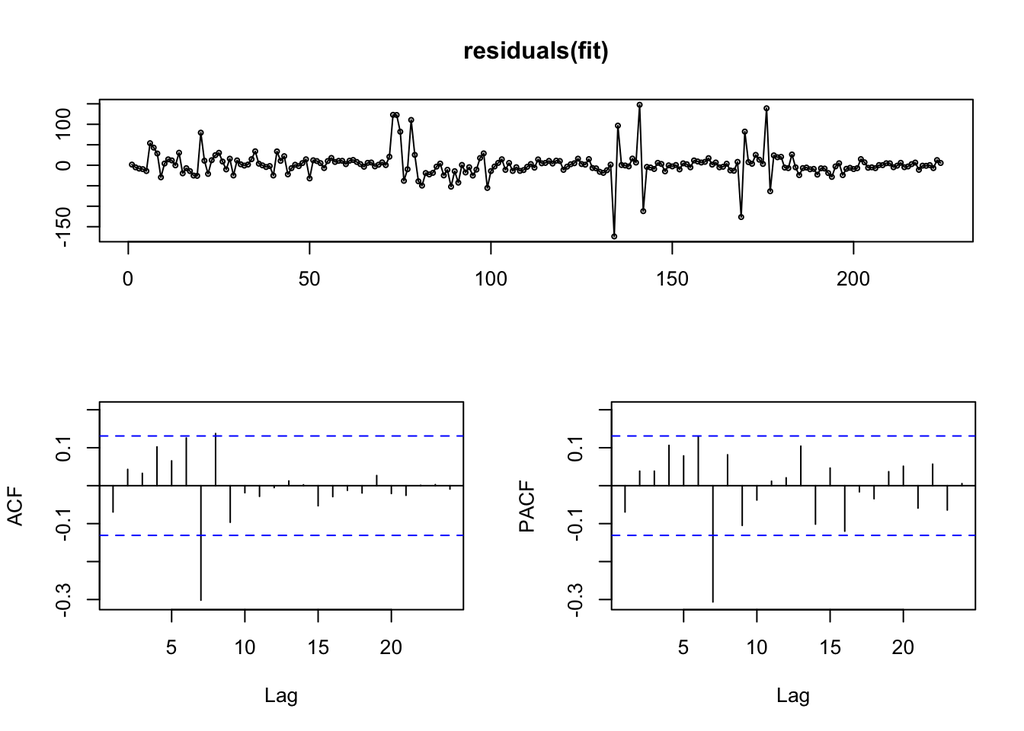

```r
# Check the residuals of the ARIMA model
tsdisplay(residuals(fit))
```

We observe that for lag=7, the residual is significantly larger than the threshold value. This may indicate that there is a weekly seasonality in the data. In fact, we see that the residuals for lags around or less than 7 are larger than for lags greater than 7. Since we know that residuals for real data are unlikely to be perfectly white noise, we can continue forward with our analysis.

#### Forecast Future Values

We will choose to forecast two weeks ahead from the data August 28, 2022. We know that around this time there was a large increase in the number of vaccine doses administered as additional boosters became available to the general public in September. We want to see how well our ARIMA model can predict this increase.

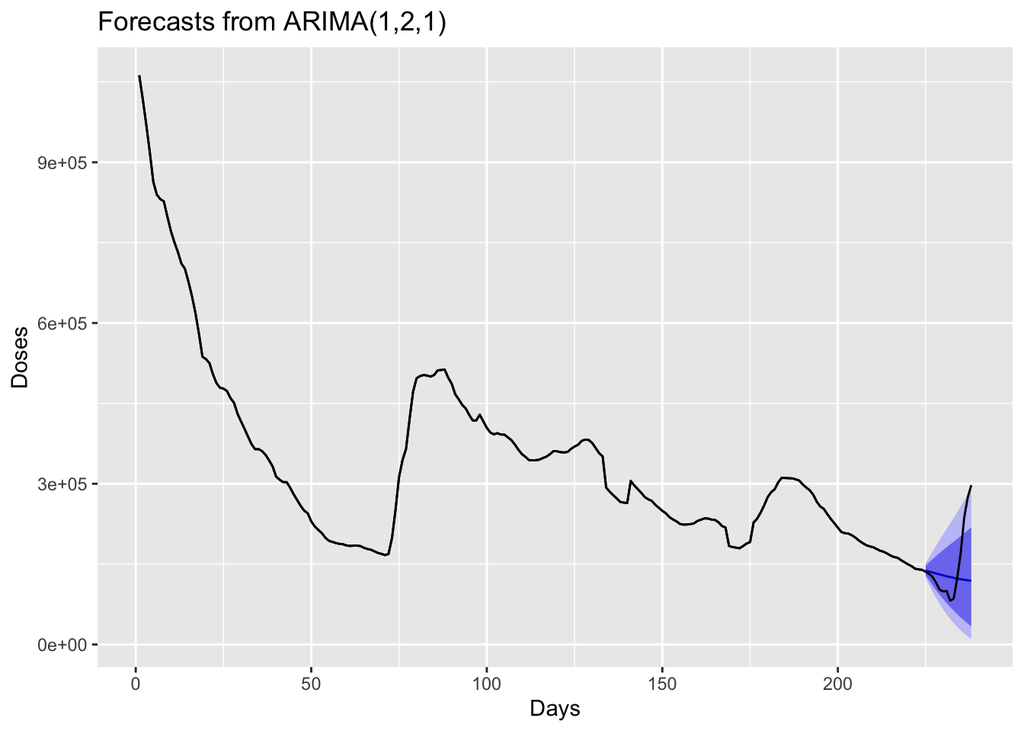

```r
# Two weeks of predictions
fit %>%
  forecast::forecast(h=14) %>%
  autoplot() +
  autolayer(ts(data[400:637, 1]), series='Data', color='black') +
  labs(x='Days', y='Doses')
```

Since we predicted two weeks ahead, the intervals are much wider than the predictions only a few days ahead. To improve upon these results, we could choose to only forecast a few days ahead and update the model and predictions each day. This would help make the model more accurate for medical professionals wanting to use it to understand potential future demand for COVID-19 vaccines.

## 5. Current Applications of ARIMA in Research

The situations for which time series analysis can be used as a tool for understanding consecutive events and their relationships are plentiful. Time series analysis can be used in fields ranging from medicine to finance and using methods like ARIMA can help model dependencies that would regularly go unnoticed. The implications of these dependencies can evolve into better treatment, a greater understanding of predictability, and can provide information for decision making.

### 5.1 ARIMA in Biological Research

As frequently mentioned within the context of biological research, collecting and preserving data about bacteria and other living things can be difficult, including the constraints of funding and variable timing. However, the use of automated data collection that provides estimates of growth and resistance can be very useful if analyzed properly. In an article about using ARIMA for antibiotic use and resistance by the European Society of Clinical Microbiology and Infectious Diseases, the problem of the coverage of studies regarding antibiotic use and resistance persisted through several iterations of conducting research and failed to account for the relationships and dependencies between variables representing use and resistance [16]. When using time sequence data, it was observed that factors such as a necessary delay in observation to accurately record the effect of antimicrobial resistance were required to analyze associations over time [17]. It is important to note that initial attempts at using time series data were not useful towards measuring this factor as data was only available on a yearly basis, therefore reinforcing the necessity of having equal time intervals to use for time series techniques (in adjacency to the property of stationarity) [17]. To prove the use of time series analysis in this context, researchers used repeated measurements of from regular surveillance of antimicrobial use and resistance, leading to the observation of variations in both variables, as well as strong correlation between time intervals. The collection of data over 60 observations over a specified time period was intentional to confirm the accuracy of observations specifically for this problem and the fickle nature of living organisms such as bacteria. Upon building an ARIMA model through a cycle of choosing models, model estimation, and checking diagnostics, the ability to predict future antimicrobial resistance was found, as well as the focus on using data within shorter time intervals of months rather than full years. These findings can be further applied to clinical settings to understand use and resistance in different environments and greater applications. Once again, time series, and more specifically ARIMA, shows the extents to which it can consider additional factors and sequential data to provide solutions for anything.

## 6. Conclusion

This tutorial introduced ARIMA as a technique for time series analysis. We initially discussed the groundwork for modeling and forecasting for time sequence data, discussing the application of techniques on time series data that requires problems over time in predictable, equal intervals. However, seasonality and trends often deter us from fulfilling this requirement, which is when we discussed methods such as differencing to turn nonstationary data stationary. The discussion of stabilizing the data brought on a comparison of another forecasting method, exponential smoothing, which we can now assess as different techniques for different types of time sequence data.

From here, we reviewed the components of an ARIMA model, namely p, the order of the autoregressive, d, the degree of first differencing, and q, the order the moving average. The values of these components can help us evaluate c, ϕ, and θ to obtain optimal model performance. Additionally, we review Akaike Information Criterion as a means for penalizing complexity, an important aspect of model selection. We also discussed the KPSS test as a hypothesis testing method for assessing optimal differencing through errors. It is here that four models are assessed to find the one with the lowest AIC, thus providing us with a model with relatively good accuracy.

In our tutorial, we reviewed the R implementation of ARIMA. We first go over the normalization of data using Box-Cox transformations. After the variance in the data has been stabilized, we reviewed the iterative process of obtaining point forecasts, and how we can use these points to predict future values. The implementation of ARIMA in R can be executed in various ways, some of which we discussed through examples.

Throughout this tutorial, ARIMA has been proven to be a powerful modeling technique that can provide useful for any time sequence data. With the framework to apply it mathematically and programmatically, we can achieve predictive forecasting results to make innovative decisions.

## Citations

1. W.-C. Juang, S.-J. Huang, F.-D. Huang, P.-W. Cheng, and S.-R. Wann, “Application of time series analysis in modelling and forecasting emergency department visits in a medical centre in Southern Taiwan,” BMJ Open, vol. 7, no. 11, p. e018628, Dec. 2017, doi: 10.1136/bmjopen-2017-018628.
2. H. O. Cekim, S. Tekin, and G. Özel, “Prediction of the earthquake magnitude by time series methods along the East Anatolian Fault, Turkey,” Earth Sci Inform, vol. 14, no. 3, pp. 1339–1348, Sep. 2021, doi: 10.1007/s12145-021-00636-z.
3. G. Athanasopoulos and R. Hyndman, “Forecasting: Principles and practice (3rd ed),” 9.8 Forecasting. [Online]. Available: https://otexts.com/fpp3/arima-forecasting.html. [Accessed: 13-Dec-2022].
4. Kwiatkowski, D., Phillips, P. C. B., Schmidt, P., & Shin, Y. (1992). Testing the null hypothesis of stationarity against the alternative of a unit root: How sure are we that economic time series have a unit root? Journal of Econometrics, 54(1-3), 159–178.Time Series Analysis and Its Applications. Accessed: Dec. 08, 2022. Available: https://link.springer.com/book/9781441978646
5. L. J. Slater et al., “Nonstationary weather and water extremes: a review of methods for their detection, attribution, and management,” Hydrol. Earth Syst. Sci., vol. 25, no. 7, pp. 3897–3935, Jul. 2021, doi: 10.5194/hess-25-3897-2021.
6. B. Wise, “Time Series Analysis with ARIMA: Part 2,” Cisco Blogs, Apr. 09, 2020. https://blogs.cisco.com/analytics-automation/arima2 (accessed Dec. 11, 2022).
7. V. A. Profillidis and G. N. Botzoris, “Trend Projection and Time Series Methods,” in Modeling of Transport Demand, Elsevier, 2019, pp. 225–270. doi: 10.1016/B978-0-12-811513-8.00006-6.
8. T. DelSole and M. K. Tippett, “Correcting the corrected AIC,” Statistics & Probability Letters, vol. 173, p. 109064, Jun. 2021, doi: 10.1016/j.spl.2021.109064.
9. Stephanie, “KPSS test: Definition and interpretation,” Statistics How To, 08-Aug-2019. [Online]. Available: https://www.statisticshowto.com/kpss-test/. [Accessed: 12-Dec-2022].
10. “Forecasting Models for Tidy Time Series.” http://fable.tidyverts.org/index.html (accessed Dec. 11, 2022).
11. L. V. D. Meer, “Spatio-Temporal Forecasts for Bike Availability in Dockless Bike Sharing Systems,” 2019, doi: 10.13140/RG.2.2.28036.88966.
12. R. L. Paige and A. A. Trindade, “The Hodrick-Prescott Filter: A special case of penalized spline smoothing,” Electron. J. Statist., vol. 4, no. none, Jan. 2010, doi: 10.1214/10-EJS570.
13. E. Mahdi, “Portmanteau test statistics for seasonal serial correlation in time series models,” SpringerPlus, vol. 5, no. 1, p. 1485, Dec. 2016, doi: 10.1186/s40064-016-3167-4.
14. “Forecasting models for tidy time series [R package fable version 0.3.2],” The Comprehensive R Archive Network, 01-Sep-2022. [Online]. Available: https://cran.r-project.org/web/packages/fable/index.html. [Accessed: 13-Dec-2022].
15. “Covid-19 Singapore - dataset by hxchua,” data.world. [Online]. Available: https://data.world/hxchua/covid-19-singapore. [Accessed: 12-Dec-2022].
16. D. L. Monet, “Making sense of antimicrobial use and resistance surveillance data …,” Clinical Microbiology and Infection. [Online]. Available: https://www.clinicalmicrobiologyandinfection.com/article/S1198-743X(15)30128-2/fulltext. [Accessed: 13-Dec-2022].
17. “Time series analysis: Definition, types, techniques, and when it’s used,” Tableau. [Online]. Available: https://www.tableau.com/learn/articles/time-series-analysis. [Accessed: 13-Dec-2022].